# midterm-exloratory analysis

Guangjin Zhou

March 8, 2019

## libraies

```r
library(ggplot2)
library(plyr)
library(gridExtra)
library(gmodels)
library(grid)
library(vcd)
library(scales)
library(pander)
library(rpart)
library(partykit)
library(randomForest)
```

# 1 Data

## Train data

### Load train data

```r
train<-read.csv('C:/Users/gxz25/Documents/471midterm/census_train.csv');head(train)
```

```
##   age         workclass fnlwgt     education education.num
## 1  45           Private 187581  Some-college            10
## 2  63  Self-emp-not-inc 196994     Bachelors            13
## 3  26           Private 122999       Masters            14
## 4  19           Private 121972       HS-grad             9
## 5  26           Private 365289       HS-grad             9
## 6  44           Private 721161  Some-college            10
##        marital.status         occupation   relationship   race   sex
## 1  Married-civ-spouse       Craft-repair        Husband  White  Male
## 2  Married-civ-spouse              Sales        Husband  White  Male
## 3       Never-married     Prof-specialty  Not-in-family  White  Male
## 4       Never-married      Other-service      Own-child  Black  Male
## 5            Divorced  Machine-op-inspct  Not-in-family  White  Male
## 6           Separated  Machine-op-inspct  Not-in-family  Black  Male
##   capital.gain capital.loss hours.per.week native.country income
## 1            0            0             40  United-States   >50K
## 2            0            0             15  United-States  <=50K
## 3         8614            0             40  United-States   >50K
## 4            0            0             40  United-States  <=50K
## 5            0            0             40  United-States  <=50K
## 6            0            0             40  United-States  <=50K
```

### Structure

```r
str(train)
```

```
## 'data.frame':    25000 obs. of  15 variables:
##  $ age           : int  45 63 26 19 26 44 33 54 48 38 ...
##  $ workclass     : Factor w/ 9 levels " ?"," Federal-gov",..: 5 7 5 5 5 5 5 5 5 5 ...
##  $ fnlwgt        : int  187581 196994 122999 121972 365289 721161 295589 174865 97863 66686 ...
##  $ education     : Factor w/ 16 levels " 10th"," 11th",..: 16 10 13 12 12 16 10 7 10 9 ...
##  $ education.num : int  10 13 14 9 9 10 13 5 13 11 ...
##  $ marital.status: Factor w/ 7 levels " Divorced"," Married-AF-spouse",..: 3 3 5 5 1 6 5 3 3 3 ...
##  $ occupation    : Factor w/ 15 levels " ?"," Adm-clerical",..: 4 13 11 9 8 8 11 5 11 8 ...
##  $ relationship  : Factor w/ 6 levels " Husband"," Not-in-family",..: 1 1 2 4 2 2 2 1 1 1 ...
##  $ race          : Factor w/ 5 levels " Amer-Indian-Eskimo",..: 5 5 5 3 5 3 3 5 5 5 ...
##  $ sex           : Factor w/ 2 levels " Female"," Male": 2 2 2 2 2 2 2 2 2 2 ...
##  $ capital.gain  : int  0 0 8614 0 0 0 0 0 0 0 ...
##  $ capital.loss  : int  0 0 0 0 0 0 0 0 0 0 ...
##  $ hours.per.week: int  40 15 40 40 40 40 50 45 45 40 ...
##  $ native.country: Factor w/ 42 levels " ?"," Cambodia",..: 40 40 40 40 40 40 40 40 23 40 ...
##  $ income        : Factor w/ 2 levels " <=50K"," >50K": 2 1 2 1 1 1 2 2 2 2 ...
```

### Missingness check

```r
apply(is.na(train),2, sum)
```

```
##            age      workclass         fnlwgt      education  education.num
##              0              0              0              0              0
## marital.status     occupation   relationship           race            sex
##              0              0              0              0              0
##   capital.gain   capital.loss hours.per.week native.country         income
##              0              0              0              0              0
```

## Test data

### Load test data

```r
test<-read.csv('C:/Users/gxz25/Documents/471midterm/census_test.csv');head(test)
```

```
##   age    workclass fnlwgt     education education.num      marital.status
## 1  54      Private 302146       HS-grad             9           Separated
## 2  35  Federal-gov  76845           9th             5  Married-civ-spouse
## 3  56    Local-gov 216851     Bachelors            13  Married-civ-spouse
## 4  54            ? 180211  Some-college            10  Married-civ-spouse
## 5  49      Private 193366       HS-grad             9  Married-civ-spouse
## 6  45      Private 386940     Bachelors            13            Divorced
##         occupation relationship                race     sex capital.gain
## 1    Other-service    Unmarried               Black  Female            0
## 2  Farming-fishing      Husband               Black    Male            0
## 3     Tech-support      Husband               White    Male            0
## 4                ?      Husband  Asian-Pac-Islander    Male            0
## 5     Craft-repair      Husband               White    Male            0
## 6  Exec-managerial    Own-child               White    Male            0
##   capital.loss hours.per.week native.country income
## 1            0             20  United-States  <=50K
## 2            0             40  United-States  <=50K
## 3            0             40  United-States   >50K
## 4            0             60          South   >50K
## 5            0             40  United-States  <=50K
## 6         1408             40  United-States  <=50K
```

### Structure

```r
str(test)
```

```
## 'data.frame':    7561 obs. of  15 variables:
##  $ age           : int  54 35 56 54 49 45 19 48 53 44 ...
##  $ workclass     : Factor w/ 8 levels " ?"," Federal-gov",..: 4 2 3 1 4 4 4 6 6 4 ...
##  $ fnlwgt        : int  302146 76845 216851 180211 193366 386940 544091 265477 88506 128354 ...
##  $ education     : Factor w/ 16 levels " 10th"," 11th",..: 12 7 10 16 12 10 12 8 10 13 ...
##  $ education.num : int  9 5 13 10 9 13 9 12 13 14 ...
##  $ marital.status: Factor w/ 7 levels " Divorced"," Married-AF-spouse",..: 6 3 3 3 3 1 2 3 3 1 ...
##  $ occupation    : Factor w/ 15 levels " ?"," Adm-clerical",..: 9 6 14 1 4 5 2 11 11 5 ...
##  $ relationship  : Factor w/ 6 levels " Husband"," Not-in-family",..: 5 1 1 1 1 4 6 1 1 5 ...
##  $ race          : Factor w/ 5 levels " Amer-Indian-Eskimo",..: 3 3 5 2 5 5 5 5 5 5 ...
##  $ sex           : Factor w/ 2 levels " Female"," Male": 1 2 2 2 2 2 1 2 2 1 ...
##  $ capital.gain  : int  0 0 0 0 0 0 0 0 0 0 ...
##  $ capital.loss  : int  0 0 0 0 0 1408 0 0 0 0 ...
##  $ hours.per.week: int  20 40 40 60 40 40 25 40 40 40 ...
##  $ native.country: Factor w/ 41 levels " ?"," Cambodia",..: 39 39 39 35 39 39 39 39 39 39 ...
##  $ income        : Factor w/ 2 levels " <=50K"," >50K": 1 1 2 2 1 1 1 1 1 1 ...
```

### Missingness check

```r
apply(is.na(test),2, sum)
```

```
##            age      workclass         fnlwgt      education  education.num
##              0              0              0              0              0
## marital.status     occupation   relationship           race            sex
##              0              0              0              0              0
##   capital.gain   capital.loss hours.per.week native.country         income
##              0              0              0              0              0
```

## Outcome

### Table summary

```r
t1<-table(train$income, useNA="always");t1
```

```
##
##  <=50K   >50K   <NA>
##  19002   5998      0
```

```r
rate1<-round(100*prop.table(t1),2)
pander(rate1)
```

| <=50K | >50K | NA |
| --- | --- | --- |
| 76.01 | 23.99 | 0 |

### Graphic summary

```r
prop.table(table(train$income))
```

```
##
##   <=50K    >50K
## 0.76008 0.23992
```

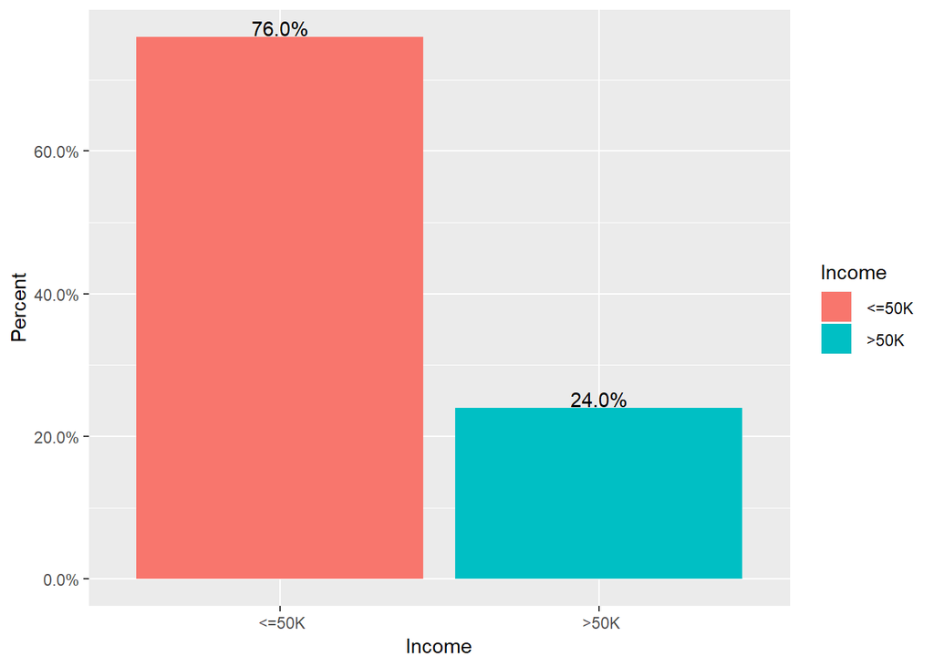

```r
ggplot(data = train, aes(x = train$income, fill = train$income)) +
  geom_bar(mapping = aes(y = (..count..)/sum(..count..))) +
  geom_text(mapping = aes(label = scales::percent((..count..)/sum(..count..)),
                      y = (..count..)/sum(..count..) ),
            stat = "count",
            vjust = -.1) +
  labs(x = "Income",
       y = "Percent",
       fill = "Income") +
  scale_y_continuous(labels = percent)
```

From train data set of 25000, 76% people make less or equal to 50K income, while 24% people make more than 50K.

## Age predictor

### Number summary

```r
fivenum(train$age); summary(train$age)
```

```
## [1] 17 28 37 48 90
```

```
##    Min. 1st Qu.  Median    Mean 3rd Qu.    Max.
##    17.0    28.0    37.0    38.6    48.0    90.0
```

### Graphic summary

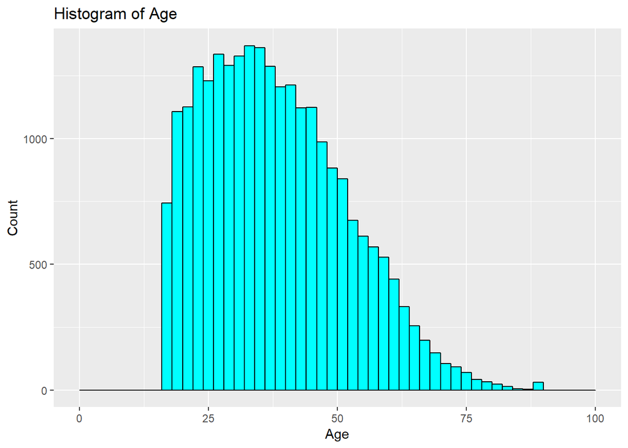

```r
qplot(x = train$age,
      data = train,
      binwidth = 5,
      color = I('black'),
      fill = I('cyan'),
      xlab = "Age",
      ylab = "Count",
      main = "Histogram of Age", breaks = seq(0, 100, 2))
```

## Gender

### Table summary

```r
t2<-table(train$sex, useNA="always");t2
```

```
##
##  Female    Male    <NA>
##    8213   16787       0
```

```r
rate2<-round(100*prop.table(t2),2)
pander(rate2)
```

| Female | Male | NA |
| --- | --- | --- |
| 32.85 | 67.15 | 0 |

### Graphic summary

```r
prop.table(table(train$sex))
```

```
##
##  Female    Male
## 0.32852 0.67148
```

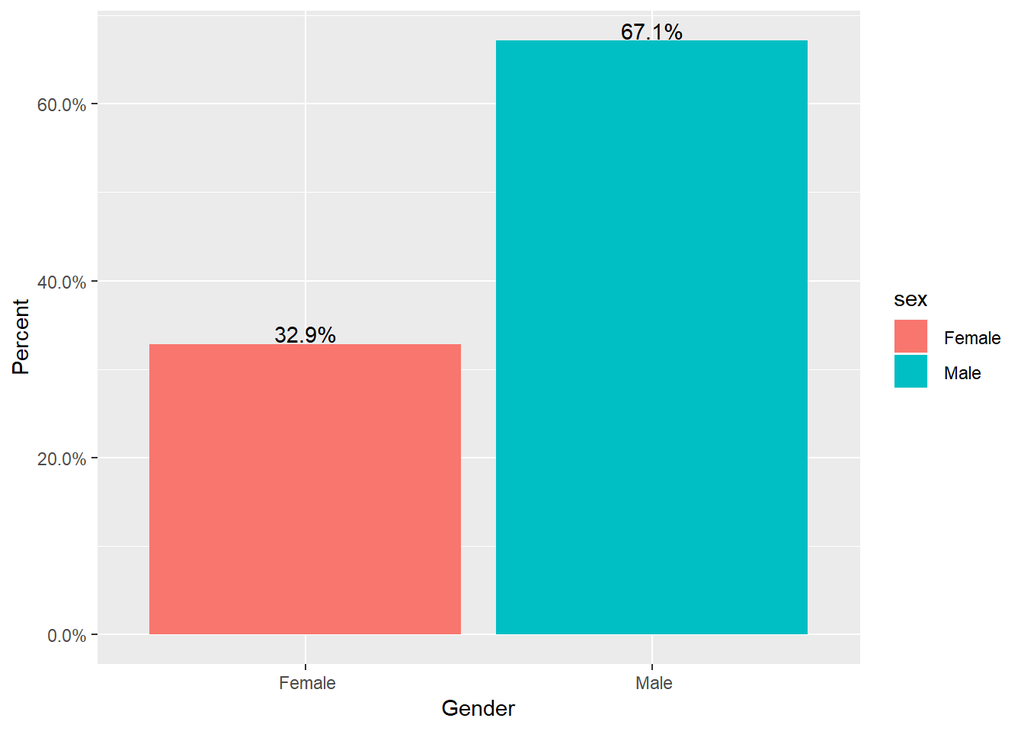

```r
ggplot(data = train, aes(x = train$sex, fill = train$sex)) +
  geom_bar(mapping = aes(y = (..count..)/sum(..count..))) +
  geom_text(mapping = aes(label = scales::percent((..count..)/sum(..count..)),
                      y = (..count..)/sum(..count..) ),
            stat = "count",
            vjust = -.1) +
  labs(x = "Gender",
       y = "Percent",
       fill = "sex") +
  scale_y_continuous(labels = percent)
```

From train data set, 67.1% sample of train dataset are male, and female only accounts for 32.9%.

## Education

### Table summary

```r
t3<-table(train$education, useNA="always");t3
```

```
##
##          10th          11th          12th       1st-4th       5th-6th
##           726           897           355           129           255
##       7th-8th           9th    Assoc-acdm     Assoc-voc     Bachelors
##           498           402           822          1062          4105
##     Doctorate       HS-grad       Masters     Preschool   Prof-school
##           311          8064          1304            35           450
##  Some-college          <NA>
##          5585             0
```

```r
rate3<-round(100*prop.table(t3),2)
pander(rate3)
```

Table continues below

| 10th | 11th | 12th | 1st-4th | 5th-6th | 7th-8th | 9th | Assoc-acdm |
| --- | --- | --- | --- | --- | --- | --- | --- |
| 2.9 | 3.59 | 1.42 | 0.52 | 1.02 | 1.99 | 1.61 | 3.29 |

Table continues below

| Assoc-voc | Bachelors | Doctorate | HS-grad | Masters | Preschool |
| --- | --- | --- | --- | --- | --- |
| 4.25 | 16.42 | 1.24 | 32.26 | 5.22 | 0.14 |

| Prof-school | Some-college | NA |
| --- | --- | --- |
| 1.8 | 22.34 | 0 |

From the summary table, the top three levels are: 32.3% of sample have high school education, 22.3% have some college education, and 16.4% have a bachelor degree.

### Graphic summary

```r
prop.table(table(train$education))
```

```
##
##          10th          11th          12th       1st-4th       5th-6th
##       0.02904       0.03588       0.01420       0.00516       0.01020
##       7th-8th           9th    Assoc-acdm     Assoc-voc     Bachelors
##       0.01992       0.01608       0.03288       0.04248       0.16420
##     Doctorate       HS-grad       Masters     Preschool   Prof-school
##       0.01244       0.32256       0.05216       0.00140       0.01800
##  Some-college
##       0.22340
```

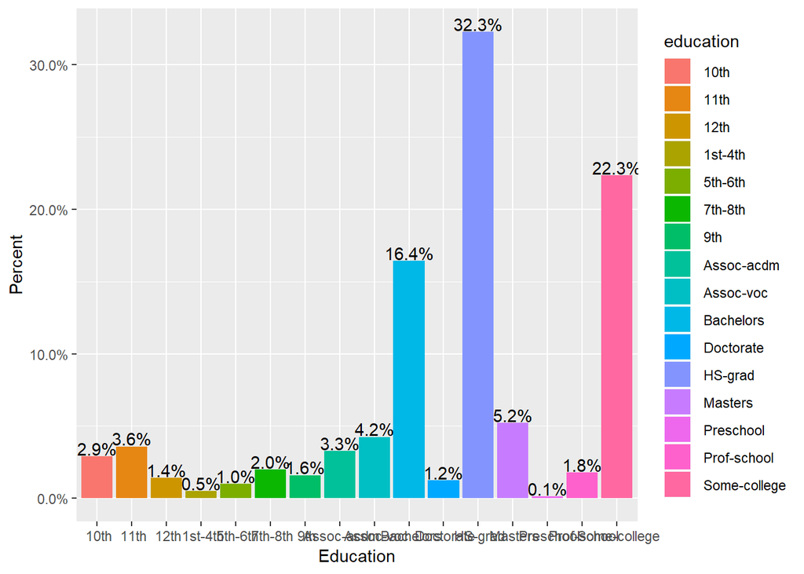

```r
ggplot(data = train, aes(x = train$education, fill = train$education)) +
  geom_bar(mapping = aes(y = (..count..)/sum(..count..))) +
  geom_text(mapping = aes(label = scales::percent((..count..)/sum(..count..)),
                      y = (..count..)/sum(..count..) ),
            stat = "count",
            vjust = -.1) +
  labs(x = "Education",
       y = "Percent",
       fill = "education") +
  scale_y_continuous(labels = percent)
```

## Marital status

### Table summary

```r
t4<-table(train$marital.status, useNA="always");t4
```

```
##
##               Divorced      Married-AF-spouse     Married-civ-spouse
##                   3425                     18                  11493
##  Married-spouse-absent          Never-married              Separated
##                    327                   8196                    790
##                Widowed                   <NA>
##                    751                      0
```

```r
rate4<-round(100*prop.table(t4),2)
pander(rate4)
```

Table continues below

| Divorced | Married-AF-spouse | Married-civ-spouse | Married-spouse-absent |
| --- | --- | --- | --- |
| 13.7 | 0.07 | 45.97 | 1.31 |

| Never-married | Separated | Widowed | NA |
| --- | --- | --- | --- |
| 32.78 | 3.16 | 3 | 0 |

From above table from train data set, we can see 46% people are married couple, 33% are never married, 14% people are divrced.

### Graphic summary

```r
prop.table(table(train$marital.status))
```

```
##
##               Divorced      Married-AF-spouse     Married-civ-spouse
##                0.13700                0.00072                0.45972
##  Married-spouse-absent          Never-married              Separated
##                0.01308                0.32784                0.03160
##                Widowed
##                0.03004
```

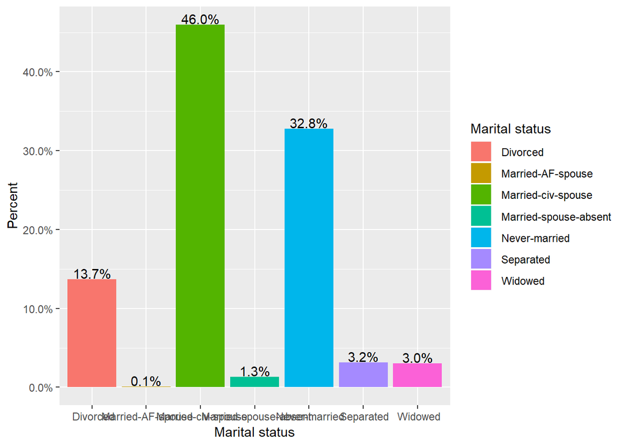

```r
ggplot(data = train, aes(x = train$marital.status, fill = train$marital.status)) +
  geom_bar(mapping = aes(y = (..count..)/sum(..count..))) +
  geom_text(mapping = aes(label = scales::percent((..count..)/sum(..count..)),
                      y = (..count..)/sum(..count..) ),
            stat = "count",
            vjust = -.1) +
  labs(x = "Marital status",
       y = "Percent",
       fill = "Marital status") +
  scale_y_continuous(labels = percent)
```

## occupation

### Table summary

```r
t5<-table(train$occupation, useNA="always");t5
```

```
##
##                  ?       Adm-clerical       Armed-Forces
##               1411               2885                  6
##       Craft-repair    Exec-managerial    Farming-fishing
##               3160               3146                770
##  Handlers-cleaners  Machine-op-inspct      Other-service
##               1051               1534               2536
##    Priv-house-serv     Prof-specialty    Protective-serv
##                114               3186                487
##              Sales       Tech-support   Transport-moving
##               2786                697               1231
##               <NA>
##                  0
```

```r
rate5<-round(100*prop.table(t5),2)
pander(rate5)
```

Table continues below

| ? | Adm-clerical | Armed-Forces | Craft-repair | Exec-managerial |
| --- | --- | --- | --- | --- |
| 5.64 | 11.54 | 0.02 | 12.64 | 12.58 |

Table continues below

| Farming-fishing | Handlers-cleaners | Machine-op-inspct | Other-service |
| --- | --- | --- | --- |
| 3.08 | 4.2 | 6.14 | 10.14 |

Table continues below

| Priv-house-serv | Prof-specialty | Protective-serv | Sales | Tech-support |
| --- | --- | --- | --- | --- |
| 0.46 | 12.74 | 1.95 | 11.14 | 2.79 |

| Transport-moving | NA |
| --- | --- |
| 4.92 | 0 |

### Graphic summary

```r
prop.table(table(train$occupation))
```

```
##
##                  ?       Adm-clerical       Armed-Forces
##            0.05644            0.11540            0.00024
##       Craft-repair    Exec-managerial    Farming-fishing
##            0.12640            0.12584            0.03080
##  Handlers-cleaners  Machine-op-inspct      Other-service
##            0.04204            0.06136            0.10144
##    Priv-house-serv     Prof-specialty    Protective-serv
##            0.00456            0.12744            0.01948
##              Sales       Tech-support   Transport-moving
##            0.11144            0.02788            0.04924
```

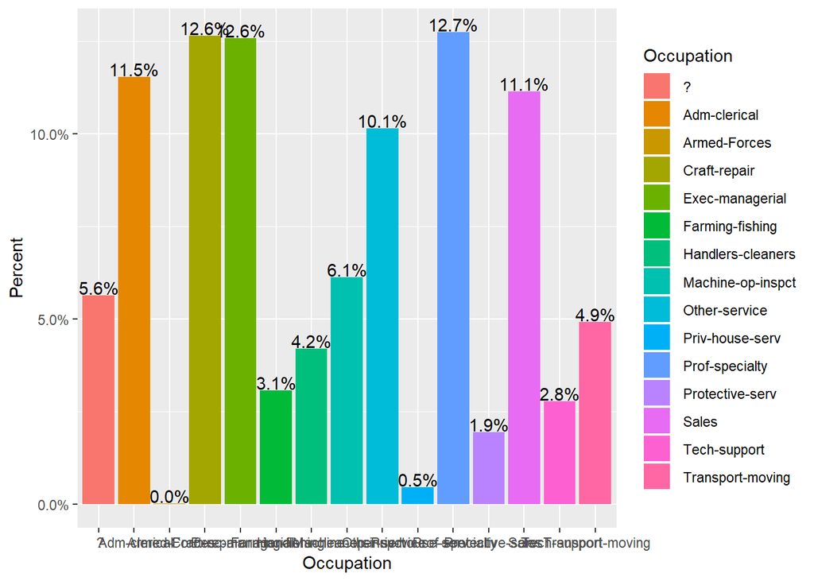

```r
ggplot(data = train, aes(x = train$occupation, fill = train$occupation)) +
  geom_bar(mapping = aes(y = (..count..)/sum(..count..))) +
  geom_text(mapping = aes(label = scales::percent((..count..)/sum(..count..)),
                      y = (..count..)/sum(..count..) ),
            stat = "count",
            vjust = -.1) +
  labs(x = "Occupation",
       y = "Percent",
       fill = "Occupation") +
  scale_y_continuous(labels = percent)
```

## Relationship

### Table summary

```r
t6<-table(train$relationship, useNA="always");t6
```

```
##
##         Husband   Not-in-family  Other-relative       Own-child
##           10117            6370             776            3887
##       Unmarried            Wife            <NA>
##            2626            1224               0
```

```r
rate6<-round(100*prop.table(t6),2)
pander(rate6)
```

| Husband | Not-in-family | Other-relative | Own-child | Unmarried | Wife | NA |
| --- | --- | --- | --- | --- | --- | --- |
| 40.47 | 25.48 | 3.1 | 15.55 | 10.5 | 4.9 | 0 |

### Graphic summary

```r
prop.table(table(train$relationship))
```

```
##
##         Husband   Not-in-family  Other-relative       Own-child
##         0.40468         0.25480         0.03104         0.15548
##       Unmarried            Wife
##         0.10504         0.04896
```

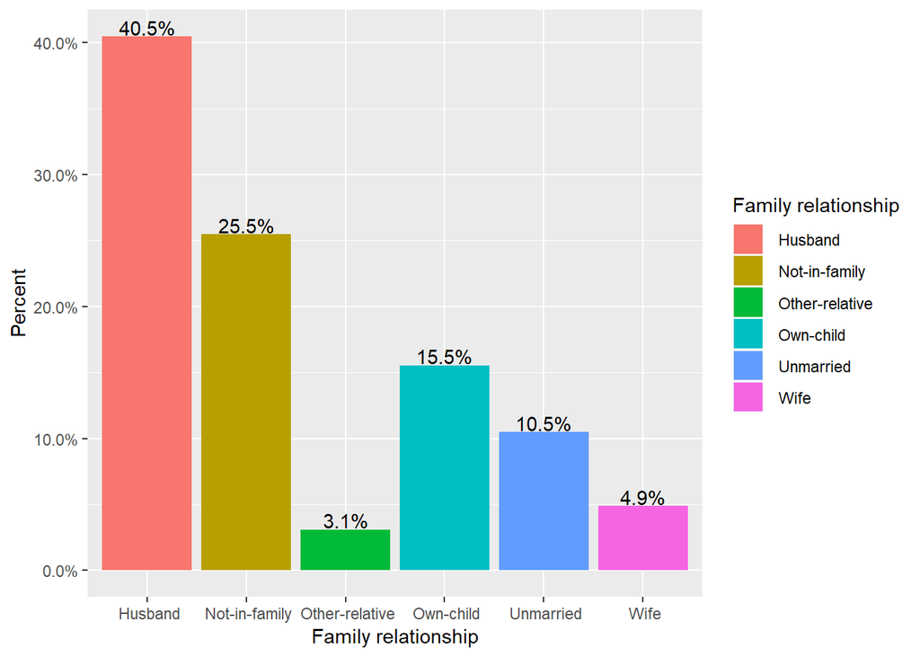

```r
ggplot(data = train, aes(x = train$relationship, fill = train$relationship)) +
  geom_bar(mapping = aes(y = (..count..)/sum(..count..))) +
  geom_text(mapping = aes(label = scales::percent((..count..)/sum(..count..)),
                      y = (..count..)/sum(..count..) ),
            stat = "count",
            vjust = -.1) +
  labs(x = "Family relationship",
       y = "Percent",
       fill = "Family relationship") +
  scale_y_continuous(labels = percent)
```

## Race

### Table summary

```r
t7<-table(train$race, useNA="always");t7
```

```
##
##  Amer-Indian-Eskimo  Asian-Pac-Islander               Black
##                 239                 806                2369
##               Other               White                <NA>
##                 216               21370                   0
```

```r
rate7<-round(100*prop.table(t7),2)
pander(rate7)
```

| Amer-Indian-Eskimo | Asian-Pac-Islander | Black | Other | White | NA |
| --- | --- | --- | --- | --- | --- |
| 0.96 | 3.22 | 9.48 | 0.86 | 85.48 | 0 |

From above table from train data set, we can see 85% people are white, 9% are black.

### Graphic summary

```r
prop.table(table(train$race))
```

```
##
##  Amer-Indian-Eskimo  Asian-Pac-Islander               Black
##             0.00956             0.03224             0.09476
##               Other               White
##             0.00864             0.85480
```

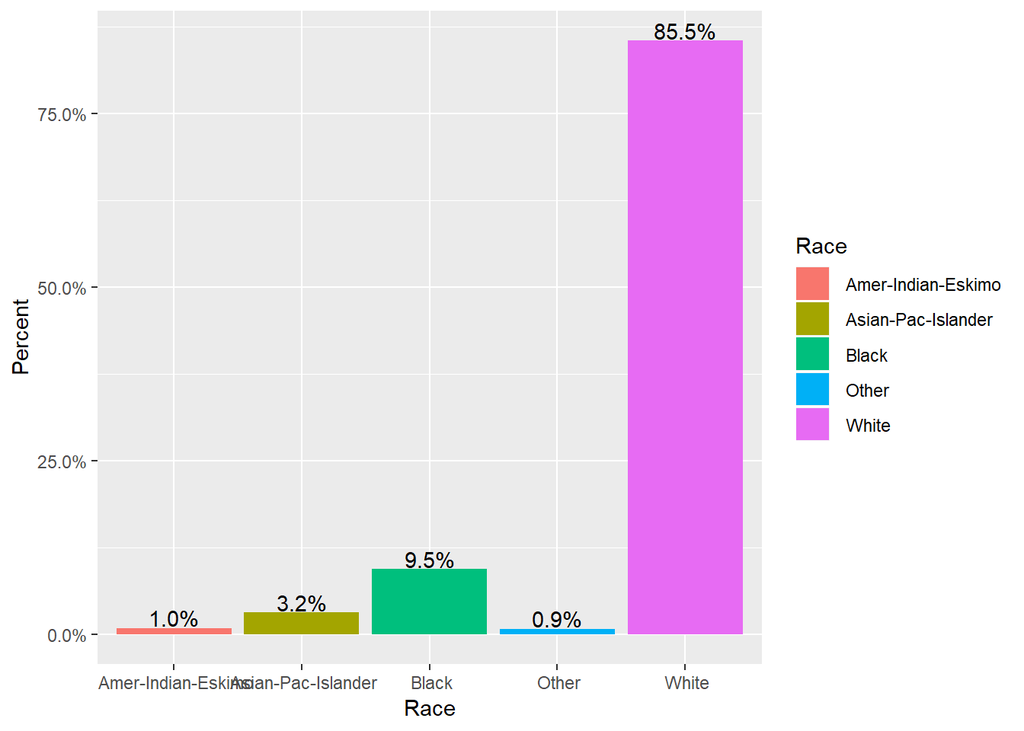

```r
ggplot(data = train, aes(x = train$race, fill = train$race)) +
  geom_bar(mapping = aes(y = (..count..)/sum(..count..))) +
  geom_text(mapping = aes(label = scales::percent((..count..)/sum(..count..)),
                      y = (..count..)/sum(..count..) ),
            stat = "count",
            vjust = -.1) +
  labs(x = "Race",
       y = "Percent",
       fill = "Race") +
  scale_y_continuous(labels = percent)
```

## capital gain predictor

### Number summary

```r
fivenum(train$capital.gain); summary(train$capital.gain)
```

```
## [1]     0     0     0     0 99999
```

```
##    Min. 1st Qu.  Median    Mean 3rd Qu.    Max.
##       0       0       0    1074       0   99999
```

The mean capital gain is 1074. Most of people don’t have capital gain.

### Graphic summary

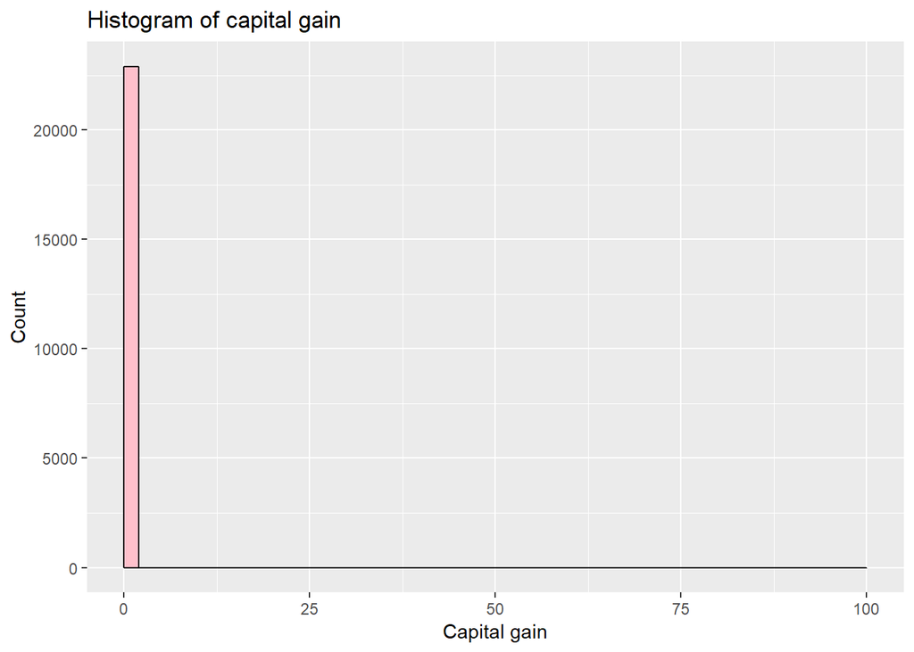

```r
qplot(x = train$capital.gain,
      data = train,
      binwidth = 0.01,
      color = I('black'),
      fill = I('pink'),
      xlab = "Capital gain",
      ylab = "Count",
      main = "Histogram of capital gain", breaks = seq(0, 100, 2))
```

## Work hour predictor

### Number summary

```r
fivenum(train$hours.per.week); summary(train$hours.per.week)
```

```
## [1]  1 40 40 45 99
```

```
##    Min. 1st Qu.  Median    Mean 3rd Qu.    Max.
##    1.00   40.00   40.00   40.41   45.00   99.00
```

The median work hour is 40, and average working hour is 40 hour.

### Graphic summary

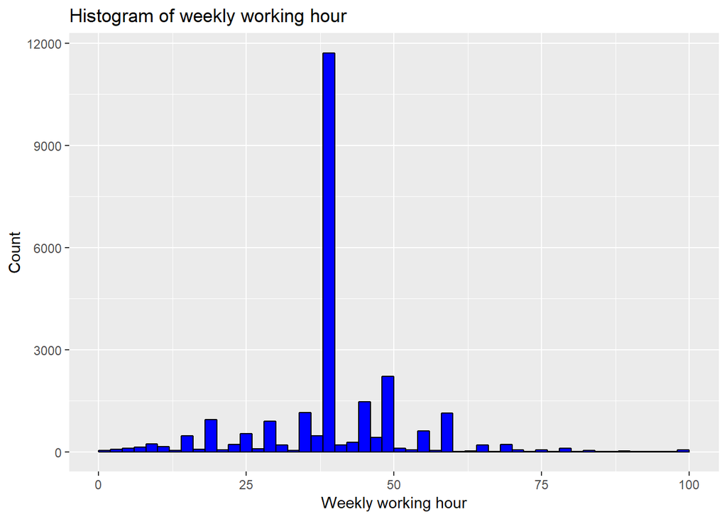

```r
qplot(x = train$hours.per.week,
      data = train,
      binwidth = 1,
      color = I('black'),
      fill = I('blue'),
      xlab = "Weekly working hour",
      ylab = "Count",
      main = "Histogram of weekly working hour", breaks = seq(0, 100, 2))
```

# 2 The exploratory analysis of outcome (income) and predictors

## Correlation of race and income

```r
chisq.test(train$race, train$income)
```

```
##
##  Pearson's Chi-squared test
##
## data:  train$race and train$income
## X-squared = 257.47, df = 4, p-value < 2.2e-16
```

```r
CrossTable(train$race, train$income,
           prop.chisq = TRUE,
           chisq = TRUE)
```

```
##
##
##    Cell Contents
## |-------------------------|
## |                       N |
## | Chi-square contribution |
## |           N / Row Total |
## |           N / Col Total |
## |         N / Table Total |
## |-------------------------|
##
##
## Total Observations in Table:  25000
##
##
##                     | train$income
##          train$race |     <=50K |      >50K | Row Total |
## --------------------|-----------|-----------|-----------|
##  Amer-Indian-Eskimo |       214 |        25 |       239 |
##                     |     5.758 |    18.241 |           |
##                     |     0.895 |     0.105 |     0.010 |
##                     |     0.011 |     0.004 |           |
##                     |     0.009 |     0.001 |           |
## --------------------|-----------|-----------|-----------|
##  Asian-Pac-Islander |       592 |       214 |       806 |
##                     |     0.694 |     2.200 |           |
##                     |     0.734 |     0.266 |     0.032 |
##                     |     0.031 |     0.036 |           |
##                     |     0.024 |     0.009 |           |
## --------------------|-----------|-----------|-----------|
##               Black |      2077 |       292 |      2369 |
##                     |    42.419 |   134.385 |           |
##                     |     0.877 |     0.123 |     0.095 |
##                     |     0.109 |     0.049 |           |
##                     |     0.083 |     0.012 |           |
## --------------------|-----------|-----------|-----------|
##               Other |       197 |        19 |       216 |
##                     |     6.562 |    20.789 |           |
##                     |     0.912 |     0.088 |     0.009 |
##                     |     0.010 |     0.003 |           |
##                     |     0.008 |     0.001 |           |
## --------------------|-----------|-----------|-----------|
##               White |     15922 |      5448 |     21370 |
##                     |     6.340 |    20.086 |           |
##                     |     0.745 |     0.255 |     0.855 |
##                     |     0.838 |     0.908 |           |
##                     |     0.637 |     0.218 |           |
## --------------------|-----------|-----------|-----------|
##        Column Total |     19002 |      5998 |     25000 |
##                     |     0.760 |     0.240 |           |
## --------------------|-----------|-----------|-----------|
##
##
## Statistics for All Table Factors
##
##
## Pearson's Chi-squared test
## ------------------------------------------------------------
## Chi^2 =  257.4735     d.f. =  4     p =  1.597375e-54
##
##
##
```

Therefore, based on above test, at the 0.05 significance level, there is strong indication that “race” and “income” are correlated.

## Correlation between workclass and income

```r
chisq.test(table(train$workclass, train$income))
```

```
##
##  Pearson's Chi-squared test
##
## data:  table(train$workclass, train$income)
## X-squared = 783.59, df = 8, p-value < 2.2e-16
```

```r
CrossTable(train$workclass, train$income, prop.chisq = TRUE, chisq = TRUE)
```

```
##
##
##    Cell Contents
## |-------------------------|
## |                       N |
## | Chi-square contribution |
## |           N / Row Total |
## |           N / Col Total |
## |         N / Table Total |
## |-------------------------|
##
##
## Total Observations in Table:  25000
##
##
##                   | train$income
##   train$workclass |     <=50K |      >50K | Row Total |
## ------------------|-----------|-----------|-----------|
##                 ? |      1252 |       152 |      1404 |
##                   |    32.019 |   101.437 |           |
##                   |     0.892 |     0.108 |     0.056 |
##                   |     0.066 |     0.025 |           |
##                   |     0.050 |     0.006 |           |
## ------------------|-----------|-----------|-----------|
##       Federal-gov |       447 |       287 |       734 |
##                   |    22.044 |    69.838 |           |
##                   |     0.609 |     0.391 |     0.029 |
##                   |     0.024 |     0.048 |           |
##                   |     0.018 |     0.011 |           |
## ------------------|-----------|-----------|-----------|
##         Local-gov |      1141 |       465 |      1606 |
##                   |     5.202 |    16.481 |           |
##                   |     0.710 |     0.290 |     0.064 |
##                   |     0.060 |     0.078 |           |
##                   |     0.046 |     0.019 |           |
## ------------------|-----------|-----------|-----------|
##      Never-worked |         7 |         0 |         7 |
##                   |     0.530 |     1.679 |           |
##                   |     1.000 |     0.000 |     0.000 |
##                   |     0.000 |     0.000 |           |
```

[output cut: 31 more lines]

```
## ------------------|-----------|-----------|-----------|
##      Column Total |     19002 |      5998 |     25000 |
##                   |     0.760 |     0.240 |           |
## ------------------|-----------|-----------|-----------|
##
##
## Statistics for All Table Factors
##
##
## Pearson's Chi-squared test
## ------------------------------------------------------------
## Chi^2 =  783.5885     d.f. =  8     p =  7.08398e-164
##
##
##
```

## Correlation between occupation and income

```r
chisq.test(table(train$occupation, train$income))
```

```
##
##  Pearson's Chi-squared test
##
## data:  table(train$occupation, train$income)
## X-squared = 3065, df = 14, p-value < 2.2e-16
```

```r
CrossTable(train$occupation, train$income, prop.chisq = TRUE, chisq = TRUE)
```

```
##
##
##    Cell Contents
## |-------------------------|
## |                       N |
## | Chi-square contribution |
## |           N / Row Total |
## |           N / Col Total |
## |         N / Table Total |
## |-------------------------|
##
##
## Total Observations in Table:  25000
##
##
##                    | train$income
##   train$occupation |     <=50K |      >50K | Row Total |
## -------------------|-----------|-----------|-----------|
##                  ? |      1259 |       152 |      1411 |
##                    |    32.441 |   102.776 |           |
##                    |     0.892 |     0.108 |     0.056 |
##                    |     0.066 |     0.025 |           |
##                    |     0.050 |     0.006 |           |
## -------------------|-----------|-----------|-----------|
##       Adm-clerical |      2503 |       382 |      2885 |
##                    |    43.872 |   138.990 |           |
##                    |     0.868 |     0.132 |     0.115 |
##                    |     0.132 |     0.064 |           |
##                    |     0.100 |     0.015 |           |
## -------------------|-----------|-----------|-----------|
##       Armed-Forces |         5 |         1 |         6 |
##                    |     0.042 |     0.134 |           |
##                    |     0.833 |     0.167 |     0.000 |
##                    |     0.000 |     0.000 |           |
##                    |     0.000 |     0.000 |           |
## -------------------|-----------|-----------|-----------|
##       Craft-repair |      2441 |       719 |      3160 |
##                    |     0.638 |     2.021 |           |
##                    |     0.772 |     0.228 |     0.126 |
##                    |     0.128 |     0.120 |           |
```

[output cut: 67 more lines]

```
## -------------------|-----------|-----------|-----------|
##       Column Total |     19002 |      5998 |     25000 |
##                    |     0.760 |     0.240 |           |
## -------------------|-----------|-----------|-----------|
##
##
## Statistics for All Table Factors
##
##
## Pearson's Chi-squared test
## ------------------------------------------------------------
## Chi^2 =  3064.966     d.f. =  14     p =  0
##
##
##
```

Therefore, based on above test, at the 0.05 significance level, there is strong indication that “occupation” and “income” are correlated.

## Correlation between marital status and income

```r
chisq.test(table(train$marital.status, train$income))
```

```
##
##  Pearson's Chi-squared test
##
## data:  table(train$marital.status, train$income)
## X-squared = 5087.3, df = 6, p-value < 2.2e-16
```

```r
CrossTable(train$marital.status, train$income, prop.chisq = TRUE, chisq = TRUE)
```

```
##
##
##    Cell Contents
## |-------------------------|
## |                       N |
## | Chi-square contribution |
## |           N / Row Total |
## |           N / Col Total |
## |         N / Table Total |
## |-------------------------|
##
##
## Total Observations in Table:  25000
##
##
##                        | train$income
##   train$marital.status |     <=50K |      >50K | Row Total |
## -----------------------|-----------|-----------|-----------|
##               Divorced |      3070 |       355 |      3425 |
##                        |    83.677 |   265.092 |           |
##                        |     0.896 |     0.104 |     0.137 |
##                        |     0.162 |     0.059 |           |
##                        |     0.123 |     0.014 |           |
## -----------------------|-----------|-----------|-----------|
##      Married-AF-spouse |         9 |         9 |        18 |
##                        |     1.602 |     5.075 |           |
##                        |     0.500 |     0.500 |     0.001 |
##                        |     0.000 |     0.002 |           |
##                        |     0.000 |     0.000 |           |
## -----------------------|-----------|-----------|-----------|
##     Married-civ-spouse |      6352 |      5141 |     11493 |
##                        |   650.390 |  2060.472 |           |
##                        |     0.553 |     0.447 |     0.460 |
##                        |     0.334 |     0.857 |           |
##                        |     0.254 |     0.206 |           |
## -----------------------|-----------|-----------|-----------|
##  Married-spouse-absent |       302 |        25 |       327 |
##                        |    11.496 |    36.420 |           |
##                        |     0.924 |     0.076 |     0.013 |
##                        |     0.016 |     0.004 |           |
```

[output cut: 19 more lines]

```
## -----------------------|-----------|-----------|-----------|
##           Column Total |     19002 |      5998 |     25000 |
##                        |     0.760 |     0.240 |           |
## -----------------------|-----------|-----------|-----------|
##
##
## Statistics for All Table Factors
##
##
## Pearson's Chi-squared test
## ------------------------------------------------------------
## Chi^2 =  5087.337     d.f. =  6     p =  0
##
##
##
```

## Correlation between family relationship and income

```r
chisq.test(table(train$relationship, train$income))
```

```
##
##  Pearson's Chi-squared test
##
## data:  table(train$relationship, train$income)
## X-squared = 5199, df = 5, p-value < 2.2e-16
```

```r
CrossTable(train$relationship, train$income, prop.chisq = TRUE, chisq = TRUE)
```

```
##
##
##    Cell Contents
## |-------------------------|
## |                       N |
## | Chi-square contribution |
## |           N / Row Total |
## |           N / Col Total |
## |         N / Table Total |
## |-------------------------|
##
##
## Total Observations in Table:  25000
##
##
##                    | train$income
## train$relationship |     <=50K |      >50K | Row Total |
## -------------------|-----------|-----------|-----------|
##            Husband |      5589 |      4528 |     10117 |
##                    |   573.891 |  1818.118 |           |
##                    |     0.552 |     0.448 |     0.405 |
##                    |     0.294 |     0.755 |           |
##                    |     0.224 |     0.181 |           |
## -------------------|-----------|-----------|-----------|
##      Not-in-family |      5728 |       642 |      6370 |
##                    |   162.238 |   513.980 |           |
##                    |     0.899 |     0.101 |     0.255 |
##                    |     0.301 |     0.107 |           |
##                    |     0.229 |     0.026 |           |
## -------------------|-----------|-----------|-----------|
##     Other-relative |       745 |        31 |       776 |
##                    |    40.826 |   129.340 |           |
##                    |     0.960 |     0.040 |     0.031 |
##                    |     0.039 |     0.005 |           |
##                    |     0.030 |     0.001 |           |
## -------------------|-----------|-----------|-----------|
##          Own-child |      3839 |        48 |      3887 |
##                    |   264.844 |   839.040 |           |
##                    |     0.988 |     0.012 |     0.155 |
##                    |     0.202 |     0.008 |           |
```

[output cut: 13 more lines]

```
## -------------------|-----------|-----------|-----------|
##       Column Total |     19002 |      5998 |     25000 |
##                    |     0.760 |     0.240 |           |
## -------------------|-----------|-----------|-----------|
##
##
## Statistics for All Table Factors
##
##
## Pearson's Chi-squared test
## ------------------------------------------------------------
## Chi^2 =  5199.021     d.f. =  5     p =  0
##
##
##
```

## Correlation between native_region and income

```r
chisq.test(table(train$native.country, train$income))
```

```
##
##  Pearson's Chi-squared test
##
## data:  table(train$native.country, train$income)
## X-squared = 246.69, df = 41, p-value < 2.2e-16
```

```r
CrossTable(train$native.country, train$income, prop.chisq = TRUE, chisq = TRUE)
```

```
##
##
##    Cell Contents
## |-------------------------|
## |                       N |
## | Chi-square contribution |
## |           N / Row Total |
## |           N / Col Total |
## |         N / Table Total |
## |-------------------------|
##
##
## Total Observations in Table:  25000
##
##
##                             | train$income
##        train$native.country |     <=50K |      >50K | Row Total |
## ----------------------------|-----------|-----------|-----------|
##                           ? |       327 |       110 |       437 |
##                             |     0.080 |     0.253 |           |
##                             |     0.748 |     0.252 |     0.017 |
##                             |     0.017 |     0.018 |           |
##                             |     0.013 |     0.004 |           |
## ----------------------------|-----------|-----------|-----------|
##                    Cambodia |         9 |         5 |        14 |
##                             |     0.253 |     0.802 |           |
##                             |     0.643 |     0.357 |     0.001 |
##                             |     0.000 |     0.001 |           |
##                             |     0.000 |     0.000 |           |
## ----------------------------|-----------|-----------|-----------|
##                      Canada |        60 |        32 |        92 |
##                             |     1.409 |     4.465 |           |
##                             |     0.652 |     0.348 |     0.004 |
##                             |     0.003 |     0.005 |           |
##                             |     0.002 |     0.001 |           |
## ----------------------------|-----------|-----------|-----------|
##                       China |        47 |        12 |        59 |
##                             |     0.104 |     0.328 |           |
##                             |     0.797 |     0.203 |     0.002 |
##                             |     0.002 |     0.002 |           |
```

[output cut: 229 more lines]

```
## ----------------------------|-----------|-----------|-----------|
##                Column Total |     19002 |      5998 |     25000 |
##                             |     0.760 |     0.240 |           |
## ----------------------------|-----------|-----------|-----------|
##
##
## Statistics for All Table Factors
##
##
## Pearson's Chi-squared test
## ------------------------------------------------------------
## Chi^2 =  246.6937     d.f. =  41     p =  3.541727e-31
##
##
##
```

89.6% people form train data set is originally come from United states.

## T test analysis of age and income

```r
t.test(age~income, data=train)
```

```
##
##  Welch Two Sample t-test
##
## data:  age by income
## t = -44.599, df = 13317, p-value < 2.2e-16
## alternative hypothesis: true difference in means is not equal to 0
## 95 percent confidence interval:
##  -7.888283 -7.224092
## sample estimates:
## mean in group  <=50K  mean in group  >50K
##             36.78476             44.34095
```

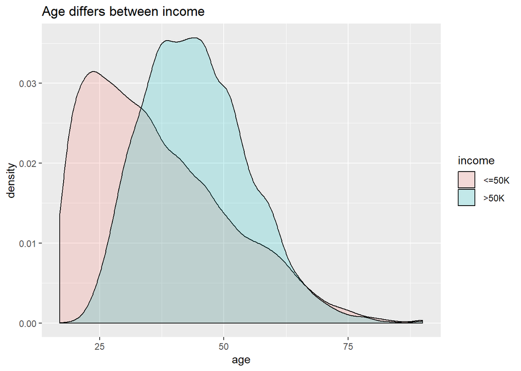

```r
ggplot(data = train, aes(age, fill = income)) +
  geom_density(alpha = 0.2)+ggtitle("Age differs between income")
```

The mean age of people who make more than 50K are 44 year old, majority of are from 25-60 year old. The mean age of people who make less or equal to 50K are 37 year old, large proportion of them are under 25 year old.

## T test analysis of work hour per week and income

```r
t.test(hours.per.week~income, data=train)
```

```
##
##  Welch Two Sample t-test
##
## data:  hours.per.week by income
## t = -40.532, df = 11029, p-value < 2.2e-16
## alternative hypothesis: true difference in means is not equal to 0
## 95 percent confidence interval:
##  -7.173873 -6.512013
## sample estimates:
## mean in group  <=50K  mean in group  >50K
##             38.76876             45.61170
```

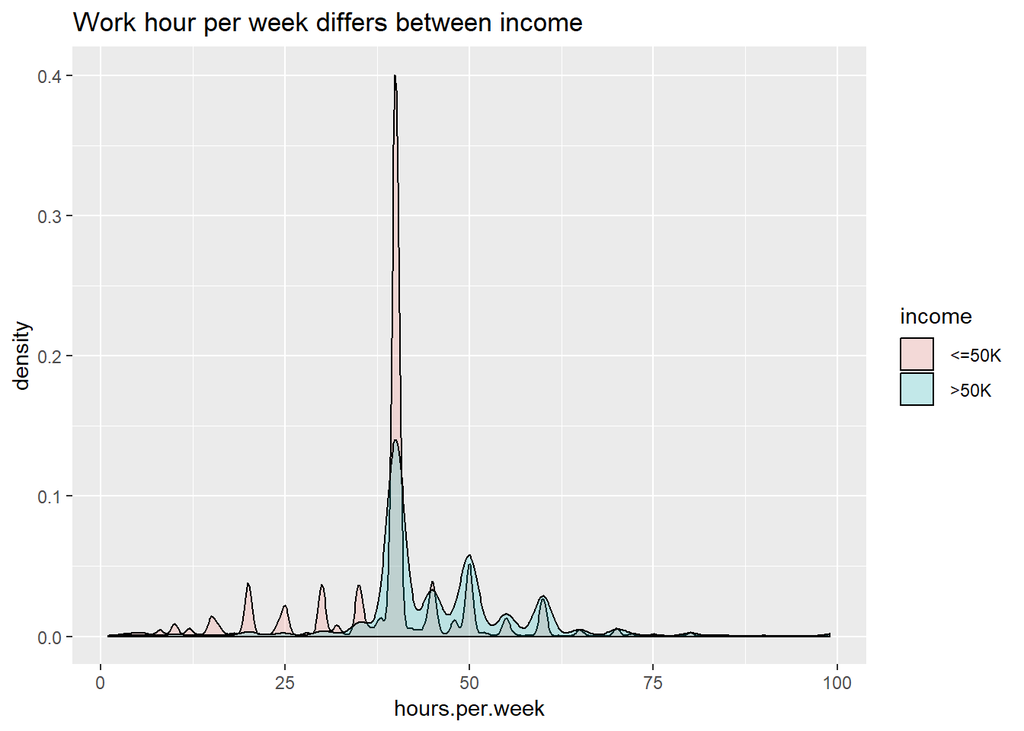

```r
ggplot(data = train, aes(hours.per.week, fill = income)) +
  geom_density(alpha = 0.2)+ggtitle("Work hour per week differs between income")
```

The mean weekly work hour of people who make more than 50K are 46 hours. The mean weekly work hour of people who make less or equal to 50K are 39 hour, large proportion of both groups work 35~40 hour per week.

## T test analysis of capital gain and income

```r
t.test(capital.gain~income, data=train)
```

```
##
##  Welch Two Sample t-test
##
## data:  capital.gain by income
## t = -20.568, df = 6011.4, p-value < 2.2e-16
## alternative hypothesis: true difference in means is not equal to 0
## 95 percent confidence interval:
##  -4235.965 -3498.751
## sample estimates:
## mean in group  <=50K  mean in group  >50K
##             146.4744            4013.8326
```

The mean capital gain of people who make more than 50K are 4013. The meancapital gain of people who make less or equal to 50K are 146, much less than the higher income class.

## T test analysis of capital loss and income

```r
t.test(capital.loss~income, data=train)
```

```
##
##  Welch Two Sample t-test
##
## data:  capital.loss by income
## t = -18.186, df = 7021.2, p-value < 2.2e-16
## alternative hypothesis: true difference in means is not equal to 0
## 95 percent confidence interval:
##  -163.0148 -131.2913
## sample estimates:
## mean in group  <=50K  mean in group  >50K
##             53.00821            200.16122
```

The mean capital loss of people who make more than 50K are 200. The meancapital loss of people who make less or equal to 50K are 53. This suggests that people who earn high income have higher capital gain and loss than those of low income. So the high income have certain capital risk, but the average capital gain (4013) is muhc larger than average capital loss (200) the higher income class.

# 3 TREE model

## Classification tree with income as outcome

```r
cart1 <- rpart(formula = income ~ ., data=train, method='class', control=rpart.control(cp=.0001, minbucket=11, maxdepth=5, xval=10))
cart1
```

```
## n= 25000
##
## node), split, n, loss, yval, (yprob)
##       * denotes terminal node
##
##  1) root 25000 5998  <=50K (0.760080000 0.239920000)
##    2) relationship= Not-in-family, Other-relative, Own-child, Unmarried 13659  880  <=50K (0.935573614 0.064426386)
##      4) capital.gain< 7073.5 13413  644  <=50K (0.951986878 0.048013122)
##        8) education= 10th, 11th, 12th, 1st-4th, 5th-6th, 7th-8th, 9th, Assoc-acdm, Assoc-voc, Bachelors, HS-grad, Preschool, Some-college 12715  467  <=50K (0.963271726 0.036728274)
##         16) capital.loss< 2218.5 12653  433  <=50K (0.965778867 0.034221133) *
##         17) capital.loss>=2218.5 62   28  >50K (0.451612903 0.548387097)
##           34) occupation= ?, Adm-clerical, Craft-repair, Farming-fishing, Machine-op-inspct, Other-service, Prof-specialty, Sales 42   17  <=50K (0.595238095 0.404761905) *
##           35) occupation= Exec-managerial, Handlers-cleaners, Protective-serv, Tech-support, Transport-moving 20    3  >50K (0.150000000 0.850000000) *
##        9) education= Doctorate, Masters, Prof-school 698  177  <=50K (0.746418338 0.253581662) *
##      5) capital.gain>=7073.5 246   10  >50K (0.040650407 0.959349593) *
##    3) relationship= Husband, Wife 11341 5118  <=50K (0.548717044 0.451282956)
##      6) education= 10th, 11th, 12th, 1st-4th, 5th-6th, 7th-8th, 9th, Assoc-acdm, Assoc-voc, HS-grad, Preschool, Some-college 7932 2649  <=50K (0.666036309 0.333963691)
##       12) capital.gain< 5095.5 7531 2256  <=50K (0.700438189 0.299561811)
##         24) occupation= ?, Armed-Forces, Craft-repair, Farming-fishing, Handlers-cleaners, Machine-op-inspct, Other-service, Priv-house-serv, Transport-moving 4651 1025  <=50K (0.779617287 0.220382713)
##           48) capital.loss< 1782.5 4516  936  <=50K (0.792736935 0.207263065) *
##           49) capital.loss>=1782.5 135   46  >50K (0.340740741 0.659259259) *
##         25) occupation= Adm-clerical, Exec-managerial, Prof-specialty, Protective-serv, Sales, Tech-support 2880 1231  <=50K (0.572569444 0.427430556) *
##       13) capital.gain>=5095.5 401    8  >50K (0.019950125 0.980049875) *
##      7) education= Bachelors, Doctorate, Masters, Prof-school 3409  940  >50K (0.275740686 0.724259314)
##       14) capital.gain< 5095.5 2898  939  >50K (0.324016563 0.675983437)
##         28) occupation= ?, Adm-clerical, Craft-repair, Farming-fishing, Handlers-cleaners, Machine-op-inspct, Other-service, Transport-moving 519  229  <=50K (0.558766859 0.441233141)
##           56) capital.loss< 1794 487  201  <=50K (0.587268994 0.412731006) *
##           57) capital.loss>=1794 32    4  >50K (0.125000000 0.875000000) *
##         29) occupation= Armed-Forces, Exec-managerial, Prof-specialty, Protective-serv, Sales, Tech-support 2379  649  >50K (0.272803699 0.727196301) *
##       15) capital.gain>=5095.5 511    1  >50K (0.001956947 0.998043053) *
```

## Tree plot

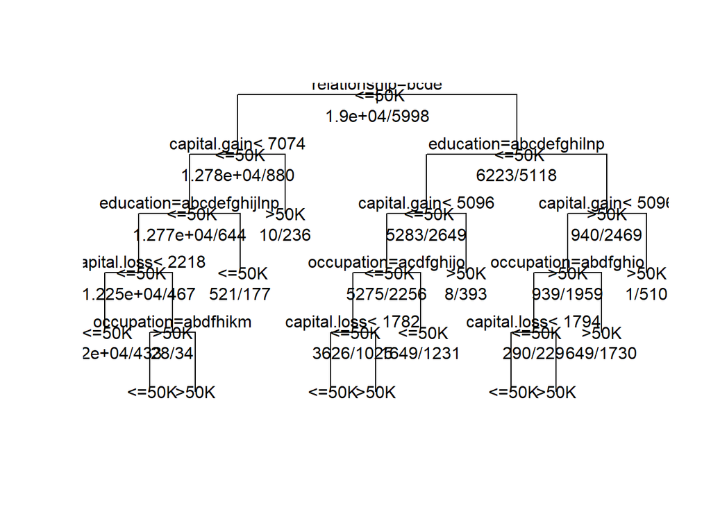

```r
plot(cart1,uniform=T); text(cart1, all=T, use.n=T)
```

## Tree prune

```r
cart2 <- prune(cart1, cp=.005)
cart2
```

```
## n= 25000
##
## node), split, n, loss, yval, (yprob)
##       * denotes terminal node
##
##  1) root 25000 5998  <=50K (0.760080000 0.239920000)
##    2) relationship= Not-in-family, Other-relative, Own-child, Unmarried 13659  880  <=50K (0.935573614 0.064426386)
##      4) capital.gain< 7073.5 13413  644  <=50K (0.951986878 0.048013122) *
##      5) capital.gain>=7073.5 246   10  >50K (0.040650407 0.959349593) *
##    3) relationship= Husband, Wife 11341 5118  <=50K (0.548717044 0.451282956)
##      6) education= 10th, 11th, 12th, 1st-4th, 5th-6th, 7th-8th, 9th, Assoc-acdm, Assoc-voc, HS-grad, Preschool, Some-college 7932 2649  <=50K (0.666036309 0.333963691)
##       12) capital.gain< 5095.5 7531 2256  <=50K (0.700438189 0.299561811) *
##       13) capital.gain>=5095.5 401    8  >50K (0.019950125 0.980049875) *
##      7) education= Bachelors, Doctorate, Masters, Prof-school 3409  940  >50K (0.275740686 0.724259314)
##       14) capital.gain< 5095.5 2898  939  >50K (0.324016563 0.675983437)
##         28) occupation= ?, Adm-clerical, Craft-repair, Farming-fishing, Handlers-cleaners, Machine-op-inspct, Other-service, Transport-moving 519  229  <=50K (0.558766859 0.441233141) *
##         29) occupation= Armed-Forces, Exec-managerial, Prof-specialty, Protective-serv, Sales, Tech-support 2379  649  >50K (0.272803699 0.727196301) *
##       15) capital.gain>=5095.5 511    1  >50K (0.001956947 0.998043053) *
```

## identify the best choice of cp, and prune

```r
bestcp1 <- cart1$cptable[which.min( cart1$cptable[,"xerror"]),"CP"];   bestcp1
```

```
## [1] 1e-04
```

```r
prune1 <- prune(cart1, cp = bestcp1);prune1
```

```
## n= 25000
##
## node), split, n, loss, yval, (yprob)
##       * denotes terminal node
##
##  1) root 25000 5998  <=50K (0.760080000 0.239920000)
##    2) relationship= Not-in-family, Other-relative, Own-child, Unmarried 13659  880  <=50K (0.935573614 0.064426386)
##      4) capital.gain< 7073.5 13413  644  <=50K (0.951986878 0.048013122)
##        8) education= 10th, 11th, 12th, 1st-4th, 5th-6th, 7th-8th, 9th, Assoc-acdm, Assoc-voc, Bachelors, HS-grad, Preschool, Some-college 12715  467  <=50K (0.963271726 0.036728274)
##         16) capital.loss< 2218.5 12653  433  <=50K (0.965778867 0.034221133) *
##         17) capital.loss>=2218.5 62   28  >50K (0.451612903 0.548387097)
##           34) occupation= ?, Adm-clerical, Craft-repair, Farming-fishing, Machine-op-inspct, Other-service, Prof-specialty, Sales 42   17  <=50K (0.595238095 0.404761905) *
##           35) occupation= Exec-managerial, Handlers-cleaners, Protective-serv, Tech-support, Transport-moving 20    3  >50K (0.150000000 0.850000000) *
##        9) education= Doctorate, Masters, Prof-school 698  177  <=50K (0.746418338 0.253581662) *
##      5) capital.gain>=7073.5 246   10  >50K (0.040650407 0.959349593) *
##    3) relationship= Husband, Wife 11341 5118  <=50K (0.548717044 0.451282956)
##      6) education= 10th, 11th, 12th, 1st-4th, 5th-6th, 7th-8th, 9th, Assoc-acdm, Assoc-voc, HS-grad, Preschool, Some-college 7932 2649  <=50K (0.666036309 0.333963691)
##       12) capital.gain< 5095.5 7531 2256  <=50K (0.700438189 0.299561811)
##         24) occupation= ?, Armed-Forces, Craft-repair, Farming-fishing, Handlers-cleaners, Machine-op-inspct, Other-service, Priv-house-serv, Transport-moving 4651 1025  <=50K (0.779617287 0.220382713)
##           48) capital.loss< 1782.5 4516  936  <=50K (0.792736935 0.207263065) *
##           49) capital.loss>=1782.5 135   46  >50K (0.340740741 0.659259259) *
##         25) occupation= Adm-clerical, Exec-managerial, Prof-specialty, Protective-serv, Sales, Tech-support 2880 1231  <=50K (0.572569444 0.427430556) *
##       13) capital.gain>=5095.5 401    8  >50K (0.019950125 0.980049875) *
##      7) education= Bachelors, Doctorate, Masters, Prof-school 3409  940  >50K (0.275740686 0.724259314)
##       14) capital.gain< 5095.5 2898  939  >50K (0.324016563 0.675983437)
##         28) occupation= ?, Adm-clerical, Craft-repair, Farming-fishing, Handlers-cleaners, Machine-op-inspct, Other-service, Transport-moving 519  229  <=50K (0.558766859 0.441233141)
##           56) capital.loss< 1794 487  201  <=50K (0.587268994 0.412731006) *
##           57) capital.loss>=1794 32    4  >50K (0.125000000 0.875000000) *
##         29) occupation= Armed-Forces, Exec-managerial, Prof-specialty, Protective-serv, Sales, Tech-support 2379  649  >50K (0.272803699 0.727196301) *
##       15) capital.gain>=5095.5 511    1  >50K (0.001956947 0.998043053) *
```

## Graphic show of tree

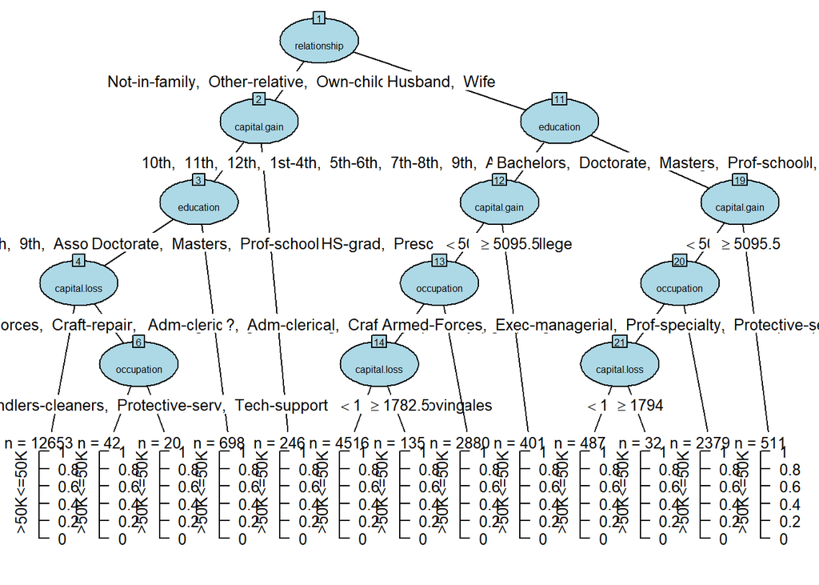

```r
cart3 <- as.party(prune1)
plot(cart3,gp=gpar(cex=.8), tnex=2, tp_args=list(fill=c("black", "white"), id=F),ip_args=list(fill="lightblue", gp=gpar(cex=.8)))
```

## Confusion matrix of train model

```r
head(predict(cart1))
```

```
##        <=50K       >50K
## 1 0.79273694 0.20726306
## 2 0.27280370 0.72719630
## 3 0.04065041 0.95934959
## 4 0.96577887 0.03422113
## 5 0.96577887 0.03422113
## 6 0.96577887 0.03422113
```

```r
table(train$income, predict(cart1, type="class"))
```

```
##
##           <=50K  >50K
##    <=50K  18281   721
##    >50K    2995  3003
```

# 4 randomForest model

## An random forest model with 2000 trees

```r
rf.model <- randomForest(income ~., data=train,ntree=2000, maxnodes=64, proximity=F,na.action=na.roughfix); rf.model
```

```
##
## Call:
##  randomForest(formula = income ~ ., data = train, ntree = 2000,      maxnodes = 64, proximity = F, na.action = na.roughfix)
##                Type of random forest: classification
##                      Number of trees: 2000
## No. of variables tried at each split: 3
##
##         OOB estimate of  error rate: 14.48%
## Confusion matrix:
##         <=50K  >50K class.error
##  <=50K  18201   801  0.04215346
##  >50K    2819  3179  0.46999000
```

### variables importance

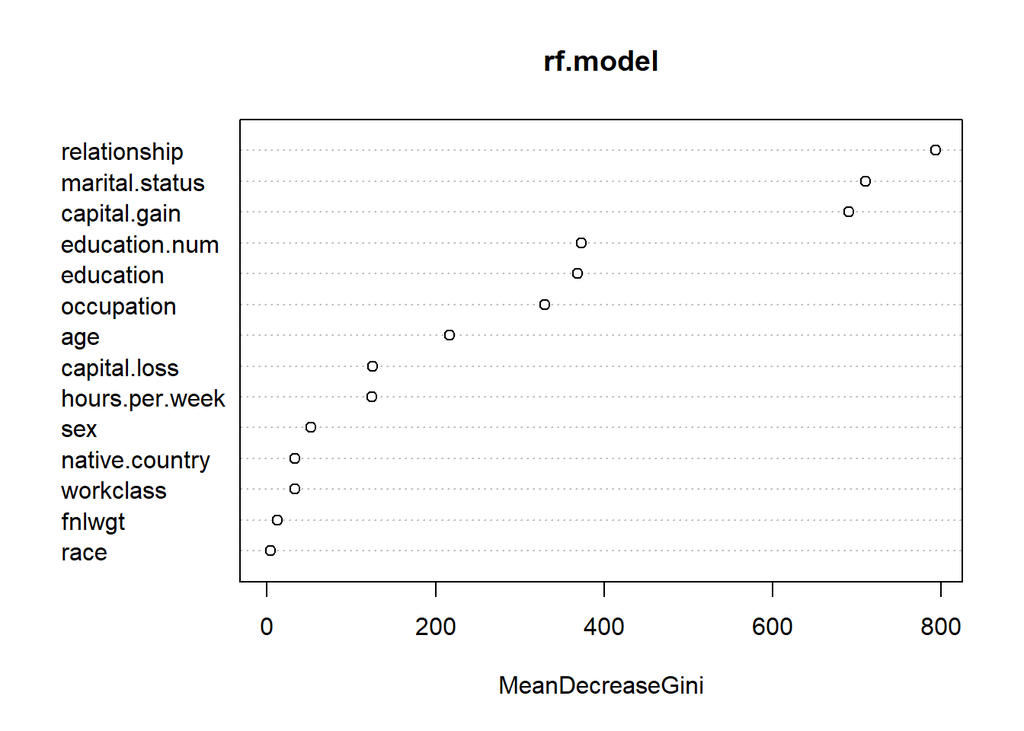

```r
varImpPlot(rf.model)
```

The random forest model suggests that relationship is the most important factor contributing to binary outcome income. Then marital status, capital gain are very important variables. Next, education, occupation, age, capital loss and weekly work hours also contribute to the model. But race, workclass, native country and gender contribute less to the model.